```python
%matplotlib inline
from __future__ import division, print_function

from scipy import stats as ss
from sklearn.preprocessing import MinMaxScaler
from statsmodels.stats import multitest
from statsmodels.regression.quantile_regression import QuantReg

import matplotlib.pyplot as plt
import numpy as np
import pandas as pd
```

# Quantile Regression Results

Quantile regression is a interesting for our problem because it:

- Is robust to non non-normal errors and outliers

  http://fmwww.bc.edu/EC-C/S2013/823/EC823.S2013.nn04.slides.pdf  
  http://www.econ.uiuc.edu/~roger/research/rq/QRJEP.pdf
- Focuses on the conditional quantiles. Allows for better interpretation of effects of variables. In a lot of cases, the effect is not on the conditional mean (OLS assumption)

  http://fmwww.bc.edu/EC-C/S2013/823/EC823.S2013.nn04.slides.pdf http://www.econ.uiuc.edu/~roger/research/rq/QRJEP.pdf
- Is robust to data representation (no need to normalize etc etc)

  http://www.econ.uiuc.edu/~roger/research/rq/QRJEP.pdf

Good ref for math mechanics: http://www.jmlr.org/papers/volume7/meinshausen06a/meinshausen06a.pdf

Nice introduction for other fields: http://www.econ.uiuc.edu/~roger/research/rq/QReco.pdf

## Quantile Regression Crash Course

Plots from: http://www.econ.uiuc.edu/~roger/research/rq/QReco.pdf

Important ref!

http://ajbuckeconbikesail.net/Econ616/Quantile/JASA1999.pdf https://www.jstor.org/stable/2669943

(this ref provides intuiton on how to use the method, for now we can ignore the math)

**First of, what do we mean by conditional quantiles**

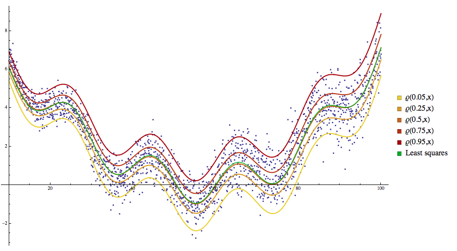

```python
from IPython.display import Image
Image(filename='ex1.png')
```

**First task**

Find out where the variables matter (left plot)

Left plot is a r-squared like value. Greater is best. But interpretation of variance does not exist. From this paper and others, I noticed that the ideia is less of trying to maximize this. It is a tool to interpret where the covariates matter.

**Second task**

Look into the effect of covaritates (right plot)

ps: I don't fully understand the middle plot, it is similar to the right one but another quality measure.

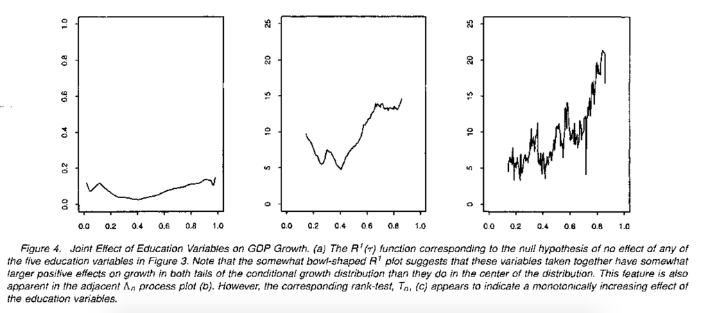

```python
from IPython.display import Image
Image(filename='ex2.png')
```

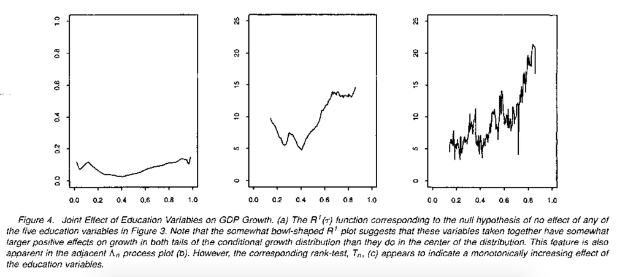

```python
from IPython.display import Image
Image(filename='ex2.png')
```

```python
df = pd.read_csv('pleasantness.dat', sep=' ')
df['graffiti'] = np.array(df['graffiti'] == 'Yes', dtype='d')
features = ['mov_cars', 'park_cars', 'debris', 'landscape',
            'mov_ciclyst', 'street_wid', 'build_ident', 'trees',
            'diff_build', 'people', 'build_height', 'graffiti']#, 'red', 'green', 'blue']
```

```
!!!!!!!!!!!!!!!
('Jovem', 'Adulto')
!!!!!!!!!!!!!!!
Looking into model quality. Extremes are better, indicating that it is where features matter
```

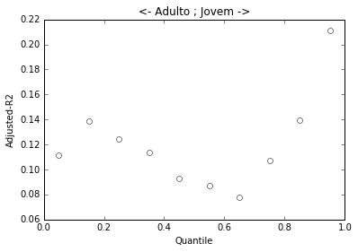

```
Number of variables w p < 0.05 per quantile
```

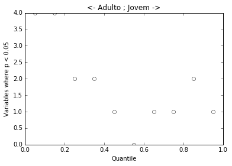

```
Looking into important variables
```

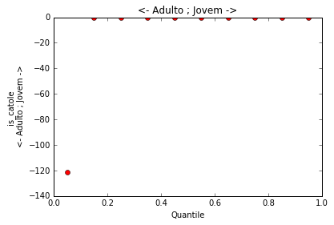

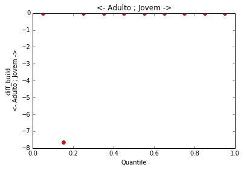

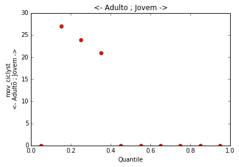

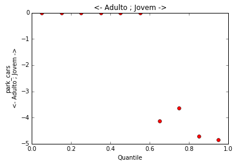

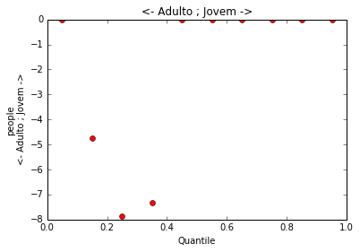

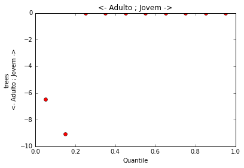

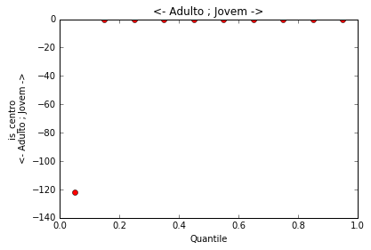

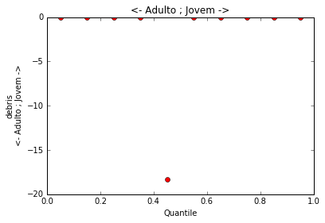

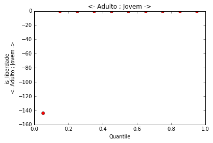

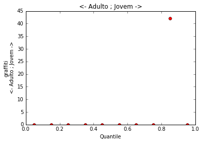

```
!!!!!!!!!!!!!!!
('Masculino', 'Feminino')
!!!!!!!!!!!!!!!
Looking into model quality. Extremes are better, indicating that it is where features matter
```

[26 more figures not shown]

```python
np.warnings.filterwarnings("ignore")
groups = [('Jovem', 'Adulto'), ('Masculino', 'Feminino'), ('Baixa', 'Media')]
for first_min_second in groups:

    print('!!!!!!!!!!!!!!!')
    print(first_min_second)
    print('!!!!!!!!!!!!!!!')

    rankg1 = df['V3.%s' % first_min_second[0]].argsort().values
    rankg2 = df['V3.%s' % first_min_second[1]].argsort().values
    response = np.array((rankg1 - rankg2), dtype='d')# ** 3
    #response = MinMaxScaler().fit_transform(response[:, None])[:, 0]
    response = pd.DataFrame(response, columns=['Rank%s-Rank%s' % first_min_second])

    explanatory = df[features].copy()
    #explanatory = pd.DataFrame(MinMaxScaler().fit_transform(explanatory.copy().values),
    #                      columns=explanatory.columns)
    #explanatory['intercept'] = np.ones(len(explanatory), dtype='d')
    explanatory['is_catole'] = np.array(df['bairro'] == 'catole', dtype='d')
    explanatory['is_centro'] = np.array(df['bairro'] == 'centro', dtype='d')
    explanatory['is_liberdade'] = np.array(df['bairro'] == 'liberdade', dtype='d')

    model = QuantReg(response, explanatory)
    max_left = 0.0
    max_left_q = 0
    max_right = 0.0
    max_right_q = 0

    rsqs = []
    qs = []
    util = []

    values = {}
    for name in explanatory.columns:
        values[name] = np.zeros(10)
        i = 0
        for q in np.linspace(0.05, 0.95, 10):
            values[name][i] = 0
            i += 1

    for i, q in enumerate(np.linspace(0.05, 0.95, 10)):
        fitted = model.fit(q=q)
        adjr2 = fitted.prsquared
        qs.append(q)
        rsqs.append(adjr2)

        for name in fitted.params[fitted.pvalues < 0.05].index:
            values[name][i] = fitted.params[name]

        util.append(sum(fitted.pvalues < 0.05))

        if q > 0.5 and adjr2 > max_right:
            max_right = adjr2
            max_right_q = q

        if q < 0.5 and adjr2 > max_left:
            max_left = adjr2
            max_left_q = q

    fitted_left = model.fit(q=max_left_q)
    good_left = fitted_left.params[fitted_left.pvalues < 0.05]

    fitted_right = model.fit(q=max_right_q)
    good_right = fitted_right.params[fitted.pvalues < 0.05]

    print('Looking into model quality. Extremes are better, indicating that it is where features matter')
    plt.title('<- %s ; %s ->' % (first_min_second[1], first_min_second[0]))
    plt.plot(qs, rsqs, 'wo')
    plt.xlabel('Quantile')
    plt.ylabel('Adjusted-R2')
    plt.show()

    print('Number of variables w p < 0.05 per quantile')
    plt.title('<- %s ; %s ->' % (first_min_second[1], first_min_second[0]))
    plt.plot(qs, util, 'wo')
    plt.xlabel('Quantile')
    plt.ylabel('Variables where p < 0.05')
    plt.show()

    print('Looking into important variables')
    for name in values:
        y = values[name]
        if y.any():
            plt.title('<- %s ; %s ->' % (first_min_second[1], first_min_second[0]))
            plt.plot(qs, y, 'ro')
            plt.xlabel('Quantile')
            plt.ylabel(name + '\n <- %s ; %s ->' % (first_min_second[1], first_min_second[0]))
            plt.show()

#     print('=====================')
#     print('What if we consider the "peak" models')
#     print('======================================')

#     print('What causes a good impression for %s' %first_min_second[0])
#     print(good_right[good_right > 0])
#     for name in good_right[good_right > 0].index:
#         plt.plot(explanatory[name], response, 'wo')
#         idx = explanatory[name].values.argsort()
#         plt.plot(explanatory[name][idx], fitted_right.predict()[idx], 'r-')
#         plt.xlabel('Value for - %s' % name)
#         plt.ylabel('Difference in Ranking')
#         plt.show()

#     print()
#     print('Bad impression')
#     print(good_right[good_right < 0])
#     for name in good_right[good_right < 0].index:
#         plt.plot(explanatory[name], response, 'wo')
#         idx = explanatory[name].values.argsort()
#         plt.plot(explanatory[name][idx], fitted_right.predict()[idx], 'r-')

#         plt.xlabel('Value for - %s' % name)
#         plt.ylabel('Difference in Ranking')
#         plt.show()

#     print()
#     print('The model for %s' %first_min_second[0])
#     print(fitted_right.summary())
#     print()
#     print()

#     print('What causes a good impression for %s' %first_min_second[1])
#     print(good_left[good_left < 0])
#     for name in good_left[good_left < 0].index:
#         plt.plot(explanatory[name], response, 'wo')
#         idx = explanatory[name].values.argsort()
#         plt.plot(explanatory[name][idx], fitted_left.predict()[idx], 'b-')
#         plt.xlabel('Value for - %s' % name)
#         plt.ylabel('Difference in Ranking')
#         plt.show()

#     print()
#     print('Bad impression')
#     print(good_left[good_left > 0])
#     for name in good_left[good_left > 0].index:
#         plt.plot(explanatory[name], response, 'wo')
#         idx = explanatory[name].values.argsort()
#         plt.plot(explanatory[name][idx], fitted_left.predict()[idx], 'b-')
#         plt.xlabel('Value for - %s' % name)
#         plt.ylabel('Difference in Ranking')
#         plt.show()

#     print()
#     print('The model for %s' %first_min_second[1])
#     print(fitted_left.summary())
#     print()
#     print()
```